# R Notebook

# 4.4 For-loops

The formula for the sum of the series $1+2+∙∙∙+n$ is $n(n+1)/2$. What if we weren’t sure that was the right function? How could we check? Using what we learned about functions we can create one that computes the $S_n$:

```r
compute_s_n <- function(n){
  x <- 1:n
  sum(x)
}
```

Perhaps the simplest example of a for-loop is this useless piece of code:

```r
for(i in 1:5){
  print(i)
}
```

```
[1] 1
[1] 2
[1] 3
[1] 4
[1] 5
```

Here is the for-loop we would write for our S_n example:

```r
m <- 25
s_n <- vector(length = m)
for(n in 1:m){
  s_n[n] <- compute_s_n(n)
}
```

In each iteration $n=1, n=2$, etc…, we compute $S_n$ and store it in the $n$th entry of `S_n`.

Now we can create a plot to search for a pattern:

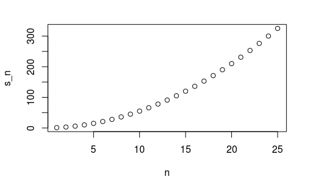

```r
n <- 1:m
plot(n, s_n)
```

If you noticed that it appears to be a quadratic, you are on the right track because the formula is $n(n+1)/2$, which we can confirm with a table:

```r
head(data.frame(s_n = s_n, formula = n*(n+1)/2))
```

|  | s_n | formula |
| --- | --- | --- |
| 1 | 1 | 1 |
| 2 | 3 | 3 |
| 3 | 6 | 6 |
| 4 | 10 | 10 |
| 5 | 15 | 15 |
| 6 | 21 | 21 |

We can also overlay the two results by using the function `lines` to draw a line over the previously plotted points:

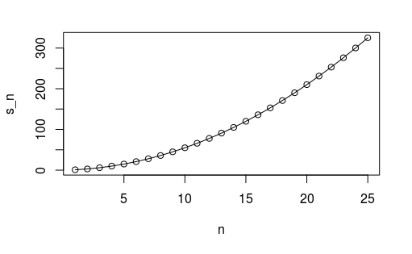

```r
plot(n, s_n)
lines(n, n*(n+1)/2)
```

# 4.5 Vectorization and functionals

Although for-loops are an important concept to understand, in R we rarely use them. As you learn more R, you will realize that vectorization is preferred over for-loops since it results in shorter and clearer code. We already saw examples in the Vector Arithmetic Section. A vectorized function is a function that will apply the same operation on each of the vectors.

```r
x <- 1:10
sqrt(x)
```

```
 [1] 1.000000 1.414214 1.732051 2.000000 2.236068 2.449490
 [7] 2.645751 2.828427 3.000000 3.162278
```

```r
y <- 1:10
x*y
```

```
 [1]   1   4   9  16  25  36  49  64  81 100
```

To make this calculation, there is no need for for-loops. However, not all functions work this way. For instance, the function we just wrote, `compute_s_n`, does not work element-wise since it is expecting a scalar. This piece of code does not run the function on each entry of `n`:

```r
n <- 1:25
compute_s_n(n)
```

```
numerical expression has 25 elements: only the first used
```

```
[1] 1
```

Functionals are functions that help us apply the same function to each entry in a vector, matrix, data frame or list. Here we cover the functional that operates on numeric, logical and character vectors: `sapply`.

The function `sapply` permits us to perform element-wise operations on any function. Here is how it works:

```r
x <- 1:10
sapply(x, sqrt)
```

```
 [1] 1.000000 1.414214 1.732051 2.000000 2.236068 2.449490
 [7] 2.645751 2.828427 3.000000 3.162278
```

Each element of `x` is passed on to the function `sqrt` and the result is returned. These results are concatenated. In this case, the result is a vector of the same length as the original `x`. This implies that the for-loop above can be written as follows:

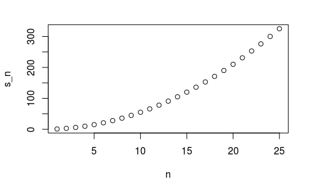

```r
n <- 1:25
s_n <- sapply(n, compute_s_n)
plot(n, s_n)
```

Other functionals are `apply`, `lapply`, `tapply`, `mapply`, `vapply`, and `replicate`. We moslty use `sapply`, `apply`, and `replicate` in this book, but we recommend familiarizing yourselves with the others as they can be very useful.

# 4.6 Exercises

1. What will this conditional expression return?

```r
x <- c(1,2,-3,4)

if(all(x>0)){
  print("All Postives")
} else{
  print("Not all positives")
}
```

```
[1] "Not all positives"
```

2. Which of the following expressions is always `FALSE` when at least one entry of a logical vector `x` is TRUE?

A.`all(x)` B.`any(x)` C.`any(!x)` D.`all(!x)`

```r
all(x)
```

```
coercing argument of type 'double' to logical
```

```
[1] TRUE
```

```r
any(x)
```

```
coercing argument of type 'double' to logical
```

```
[1] TRUE
```

```r
any(!x)
```

```
[1] FALSE
```

```r
all(!x)
```

```
[1] FALSE
```

The answer is **D**

3. The function `nchar` tells you how many characters long a character vector is.

Write a line of code that assigns to the object `new_names` the state abbreviation when the state name is longer than 8 characters.

```r
library(dslabs)
data(murders)
```

```r
new_names <- ifelse(nchar(murders$state)>8, murders$abb, murders$state)
new_names
```

```
 [1] "Alabama"  "Alaska"   "Arizona"  "Arkansas" "CA"
 [6] "Colorado" "CT"       "Delaware" "DC"       "Florida"
[11] "Georgia"  "Hawaii"   "Idaho"    "Illinois" "Indiana"
[16] "Iowa"     "Kansas"   "Kentucky" "LA"       "Maine"
[21] "Maryland" "MA"       "Michigan" "MN"       "MS"
[26] "Missouri" "Montana"  "Nebraska" "Nevada"   "NH"
[31] "NJ"       "NM"       "New York" "NC"       "ND"
[36] "Ohio"     "Oklahoma" "Oregon"   "PA"       "RI"
[41] "SC"       "SD"       "TN"       "Texas"    "Utah"
[46] "Vermont"  "Virginia" "WA"       "WV"       "WI"
[51] "Wyoming"
```

4. Create a function `sum_n` that for any given value, say $n$, computes the sum of the integers from 1 to n (inclusive). Use the function to determine the sum of integers from 1 to 5,000.

```r
sum_n <- function(n){
  x <- 1:n
  sum(x)
}
sum_n(5000)
```

```
[1] 12502500
```

5. Create a function `altman_plot` that takes two arguments, `x` and `y`, and plots the difference against the sum.

```r
altman_plot <- function(x, y){
  plot(x+y, x-y)
}
```

6. After running the code below, what is the value of `x`?

```r
x <- 3
my_func <- function(y){
  x <- 5
  y+5
}
x
```

```
[1] 3
```

7. Write a function compute_s_n that for any given $n$ computes the sum $Sn=1^2+2^2+3^2+...n^2$. Report the value of the sum when $n=10$.

```r
compute_s_n <- function(n){
  x <- 1:n
  sum(x^2)
}
compute_s_n(10)
```

```
[1] 385
```

8. Define an empty numerical vector `s_n` of size 25 using `s_n <- vector("numeric", 25)` and store in the results of $S1, S2, ..., S25$ using a for-loop.

```r
s_n <- vector("numeric", 25)
n <- 1:25
for(i in n){
  s_n[i] <- compute_s_n(i)
}
s_n
```

```
 [1]    1    5   14   30   55   91  140  204  285  385  506  650
[13]  819 1015 1240 1496 1785 2109 2470 2870 3311 3795 4324 4900
[25] 5525
```

9. Repeat exercise 8, but this time use `sapply`.

```r
n <- 1:25
s_n <- sapply(n, compute_s_n)
s_n
```

```
 [1]    1    5   14   30   55   91  140  204  285  385  506  650
[13]  819 1015 1240 1496 1785 2109 2470 2870 3311 3795 4324 4900
[25] 5525
```

10. Repeat exercise 8, but this time use `map_dbl`.

```r
library(purrr)
s_n <- map_dbl(n, compute_s_n)
s_n
```

```
 [1]    1    5   14   30   55   91  140  204  285  385  506  650
[13]  819 1015 1240 1496 1785 2109 2470 2870 3311 3795 4324 4900
[25] 5525
```

처음 R Chunk에 `s_n <- map_dbl(n, compute_s_n)` 와 `s_n` 만을 넣었을 때 `Error in map_dbl(n, compute_s_n) : could not find function "map_dbl"` 라는 error가 떠서 goolging을 통해 `library(purrr)`을 기입해주어야만 `map_dbl` function을 사용할 수 있음을 깨달았다.

11. Plot $Sn$ versus $n$. Use points defined by $n=1,...,25$.

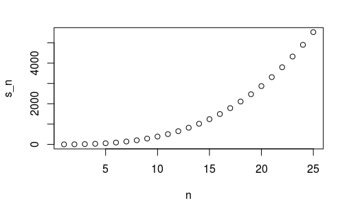

```r
plot(n, s_n)
```

12. Confirm that the formula for this sum is $Sn=n(n+1)(2n+1)/6$.

```r
s_n == n*(n+1)*(2*n+1)/6
```

```
 [1] TRUE TRUE TRUE TRUE TRUE TRUE TRUE TRUE TRUE TRUE TRUE TRUE
[13] TRUE TRUE TRUE TRUE TRUE TRUE TRUE TRUE TRUE TRUE TRUE TRUE
[25] TRUE
```